# Mapping Obesity: A County-Level Analysis of Lifestyle and Food Environment Factors

SURE 2025

**Helen Peng**  
Carnegie Mellon University

**Jordan Faustin**  
Howard University

**Anvith Thumma**  
Arizona State University

## Significance

- **Public Health Implications:**  
  Obesity is a major contributor to rising healthcare costs and chronic diseases such as diabetes, heart disease, and cancer.
- **Social Factors of Health:**  
  Physical Inactivity and food access are modifiable factors linked to obesity. In turn, studying their impact can highlight how our environment and infrastructure, like our parks, grocery stores, and schools, can shape our health outcomes.
- **Policy and Community Planning:**  
  New information revealed through findings can help to make informed policies for urban planning in under-served areas and school/workplace wellness programs.

## Does physical inactivity level and access to healthy food affect obesity rate at the county level?

## Agenda

- **Data Overview**
- **Initial Analysis**
- **Understanding Direction**
- **Modeling and Comparison**
- **Discussion**
- **Recommendations**
- **Appendix**

## As Physical Inactivity increases Obesity Rates increase as well, and as the Food Environment Index increase Obesity Rates start to decline

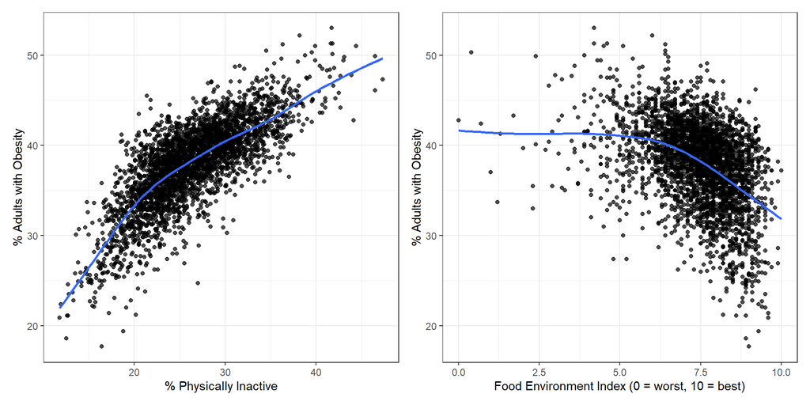

## Obesity Rates are notably higher in the Midwest and South compared to the Northeast and West

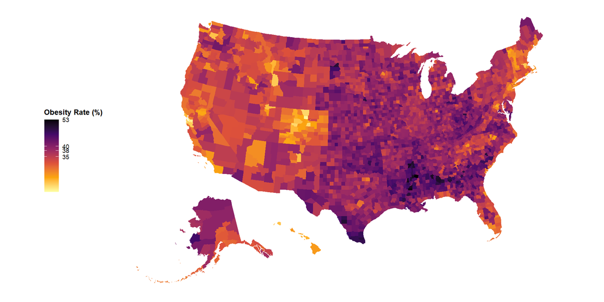

## Fuel or Fire

There is a relationship between obesity rates, physical inactivity, and healthy food environments. Now we want to confirm whether we’re looking at the “Fuel” or the “Fire” of the situation. Reasoning behind this process is to clarify that we are targeting a driver and not a symptom.

## Huber Regression Model (Obesity)

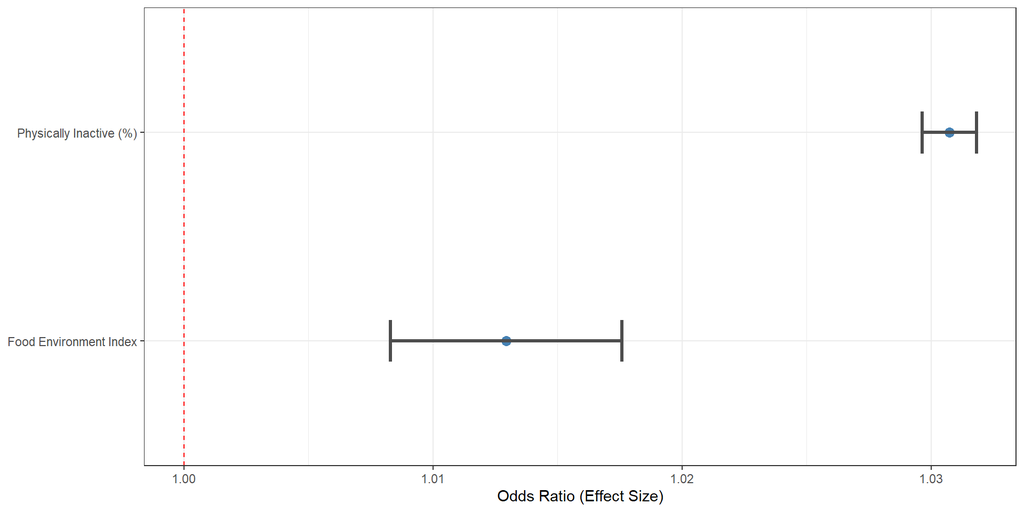

## Surprisingly, the Food Environment Index does not rank among the top predictors

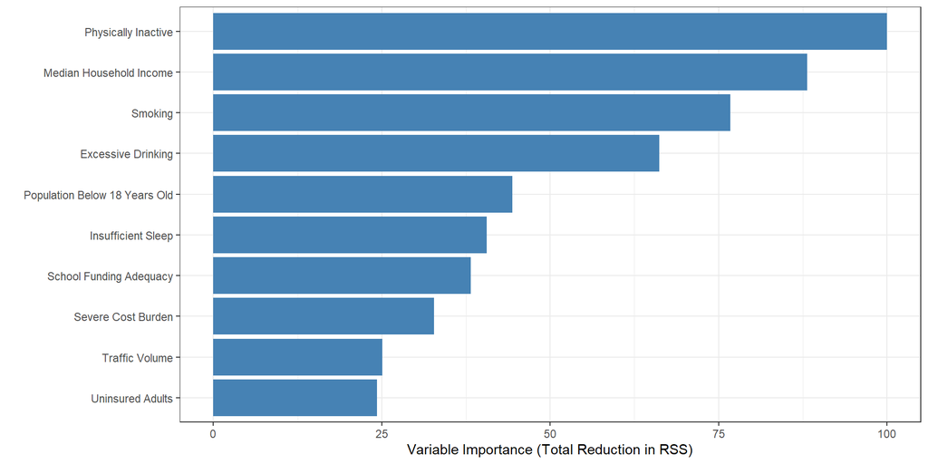

## Key Takeaways

- **Physical Inactivity** is the strongest and most consistent predictor of obesity.
- **Food Insecurity Percentage** becomes a statistically significant predictor once we control for physical inactivity and drop FEI.
- **Access to Healthy Food Percentage** is not statistically significant in any specification we tested.
- Relying on the FEI alone is misleading because its signal disappears once key components (and physical inactivity) are included.

## Recommendations

#### Prioritize Physical Activity Infrastructure

- Building walkable Communities (expanding sidewalks, bike lanes, and trails in high-obesity counties)
- Funding Safe Routes to School programs to improve sidewalks, crosswalks, and safety patrols.

#### Improve Food Access with Targeted Interventions

- Deploying Mobile Food Solutions such as produce vans (e.g., Veggie Van in NC) in food deserts. and hosting pop-up markets paired with nutrition workshops.

#### Redirecting Funding

- Shifting resources from FEI-based programs to hyper-local initiatives (e.g., subsidized CSA boxes for low-income families).

## Possible Future Work

- Establishing a count of parks and wellness centers per county
- Mapping their respective distance and location
- Checking for trends on when individuals are going to the fitness locations

## Appendix

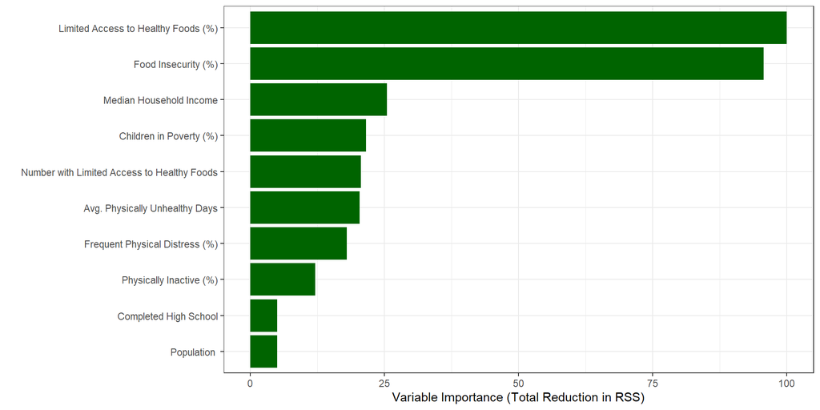

Comparison of Linear and Huber Robust Models for Obesity Prediction

| Model | Food Environment Index (SE) | Physically Inactive (SE) | R-squared | Residual SE |
| --- | --- | --- | --- | --- |
| Linear Model (OLS) | 0.0110 (0.0038) | 0.0309 (0.0008) | 0.5548 | 0.1317 |
| Huber Robust Model | 0.0147 (0.0036) | 0.0304 (0.0008) | N/A | 0.1177 |

## Appendix

Comparison of Obesity Prediction Models

| term | estimate | std.error | statistic | p.value |
| --- | --- | --- | --- | --- |
| (Intercept) | -1.3849 | 0.0456 | -30.3608 | 0.0000 |
| food_environment_index | 0.0110 | 0.0038 | 2.9075 | 0.0037 |
| percent_physically_inactive | 0.0309 | 0.0008 | 36.9735 | 0.0000 |

| term | estimate | std.error | statistic |
| --- | --- | --- | --- |
| (Intercept) | -1.3962 | 0.0432 | -32.3408 |
| food_environment_index | 0.0147 | 0.0036 | 4.1236 |
| percent_physically_inactive | 0.0304 | 0.0008 | 38.5002 |

| term | estimate | std.error | statistic | p.value |
| --- | --- | --- | --- | --- |
| (Intercept) | -1.2499 | 0.0176 | -71.2004 | 0.000 |
| percent_physically_inactive | 0.0325 | 0.0010 | 34.0182 | 0.000 |
| percent_limited_access_to_healthy_foods | 0.0001 | 0.0005 | 0.1446 | 0.885 |
| percent_food_insecure | -0.0065 | 0.0015 | -4.4469 | 0.000 |

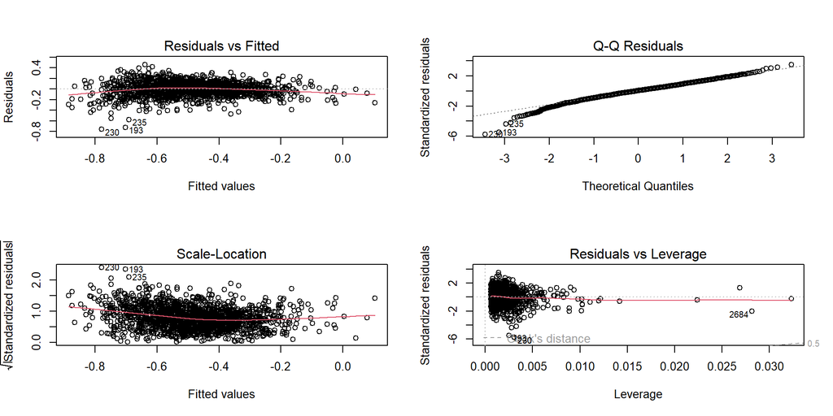

```
            percent_physically_inactive percent_limited_access_to_healthy_foods
                               2.210069                                1.095520
                  percent_food_insecure
                               2.244116
```

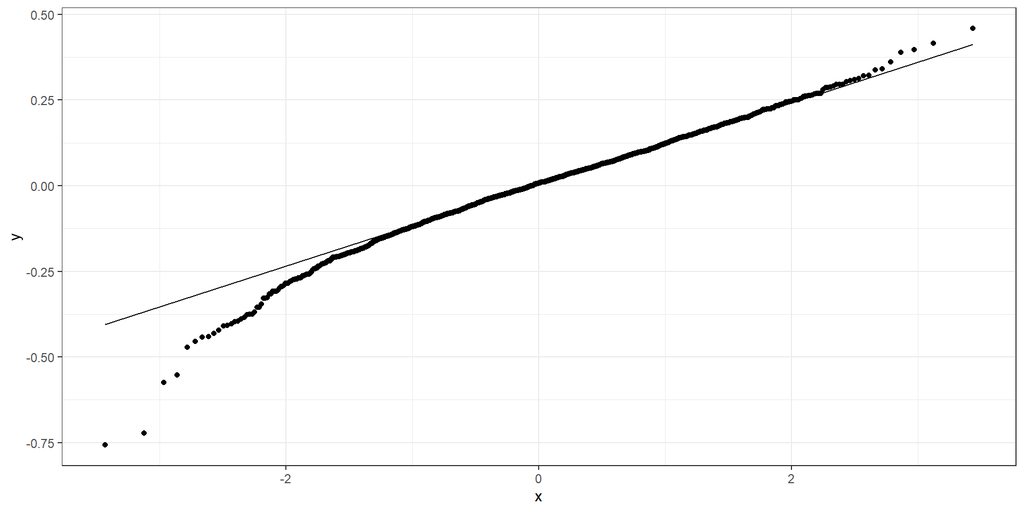